# DETERMINACIÓN DE LA SENSIBILIDAD DEL RAQUIS A LA DESHIDRATACIÓN EN POSCOSECHA BASADA EN PARÁMETROS DE COSECHA

Author

Jhonatan Loayza

## Introducción

El pardeamiento es un fenómeno fisiológico común en frutas y hortalizas que afecta la apariencia y reduce la aceptación del consumidor, constituyendo un desafío relevante para la industria alimentaria. En uva de mesa, la cosecha se determina principalmente mediante parámetros de madurez como °Brix y acidez titulable, sin considerar el estado fisiológico del raquis, pese a su importancia para la vida poscosecha del racimo. Estudios recientes muestran que el cambio de color del raquis ocurre de forma paralela a la maduración de las bayas y se asocia con la disminución del contenido relativo de agua (CRA) del tejido, lo que favorece la degradación pigmentaria y la aparición de pardeamiento (Fang et al., 2015).

```python
# Import librerias necesarias
import pandas as pd
import openpyxl
import numpy as np
import seaborn as sns
import matplotlib.pyplot as plt
import matplotlib.colors as mcolors
from sklearn.metrics import r2_score, mean_squared_error
from sklearn.linear_model import LinearRegression
```

## Resultados

### 1. Caracterización inicial a cosecha

La cosecha se realizó en el estado de madurez determinado por cada productor, siguiendo los criterios comerciales establecidos para uva de mesa (Tabla 1). Los sólidos solubles totales (STT) fluctuaron entre 17 % - 19%, mientras que la acidez titulable se mantuvo en rangos optmimos (0.51 % - 0.78%).

```python
Cosecha = pd.read_excel(r'../datos/caracterizacion inicial.xlsx')
df = pd.DataFrame(Cosecha)

df.columns = df.columns.str.strip() # Normalizar nombres de columnas

# Filtro de datos de acuerdo evaluacion 0h,3h,18h
df_filtrado = df[df["Evaluacion"].isin(["E00", "E03", "E18"])]

# Tabla resumen de caracterizacion inicial
df_resumen =(df_filtrado.groupby('Variedad')
             [['TSS','Acidez_titulable', 'Peso', 'Calibre_Ecuatorial', 'Firmeza']]
.agg(['mean', 'std','count'])
.round(2)
.reset_index()
)
# creamos un tabal media + DE
tabla_resumen = pd.DataFrame()
tabla_resumen["Variedad"] = df_resumen["Variedad"]

for var in ["TSS", "Acidez_titulable", "Peso", "Calibre_Ecuatorial", "Firmeza"]:
    tabla_resumen[var] = df_resumen.apply(
        lambda x: f"{x[(var, 'mean')]:.2f} ± {x[(var, 'std')]:.2f}", axis=1
    )

# Renombrar encabezados
tabla_resumen = tabla_resumen.rename(columns={
    "TSS": "TSS (°Brix)",
    "Acidez_titulable": "Acidez Titulable (g/L)",
    "Peso": "Peso (g)",
    "Calibre_Ecuatorial": "Calibre (mm)",
    "Firmeza": "Firmeza (gf mm-1)"
})

tabla_resumen
```

|  | Variedad | TSS (°Brix) | Acidez Titulable (g/L) | Peso (g) | Calibre (mm) | Firmeza (gf mm-1) |
| --- | --- | --- | --- | --- | --- | --- |
| 0 | AL | 19.04 ± 1.04 | 0.64 ± 0.07 | 10.18 ± 1.82 | 22.57 ± 1.58 | 322.48 ± 64.59 |
| 1 | SC | 18.04 ± 0.80 | 0.78 ± 0.09 | 9.03 ± 1.61 | 23.60 ± 1.54 | 242.69 ± 18.44 |

Tabla 1. Caracterización inicial en cosecha, cv. Allison y S. Celebretion.(media ± DE)

### 2. Relación del hue inicial, Contenido Relativo del agua en cosecha.

La relación entre el color inicial del raquis (Hue en cosecha) y el color final tras 10 días de almacenamiento a 0 °C mostró un comportamiento diferencial entre las variedades evaluadas (Figura 1). En Allison (AL), el Hue inicial explicó de manera moderada la variación del Hue final (R² = 0.74), con una pendiente positiva (y = 1.39x – 17.31), lo que indica que los racimos con mayor tonalidad verde en cosecha mantuvieron valores más altos de Hue después del almacenamiento, aunque con una dispersión apreciable en los datos.

Por el contrario, en Sweet Celebration (SC) se observó una relación más estrecha entre ambas variables (R² = 0.90), con una pendiente mayor (y = 2.27x – 50.08). Esto sugiere que en esta variedad el Hue inicial es un predictor más robusto del color final, evidenciando una sensibilidad más marcada a los cambios de tonalidad durante el almacenamiento. La mayor pendiente indica que pequeños incrementos en el Hue inicial se traducen en mayores incrementos en el Hue final en comparación con Allison.

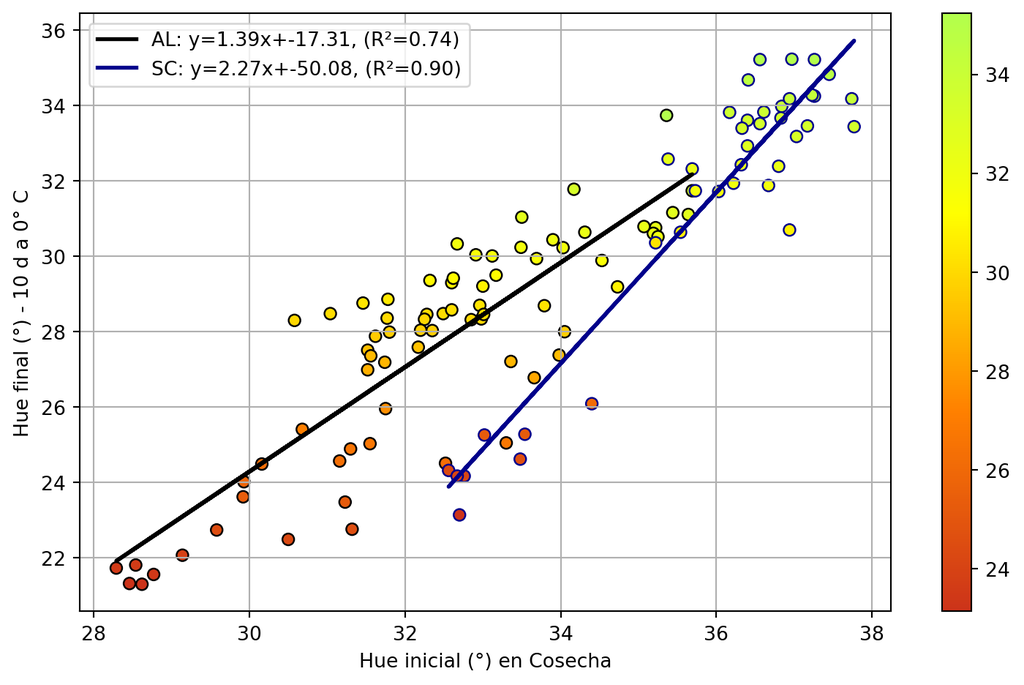

Figura 1. Relación de Hue (°) en cosecha y el Hue(°) final despues de almacenamiento (10 días a 0°C)

```python
# Cargamos archivos
# =====================================================================================
datos_correlacion = pd.read_csv(r'../datos/Pardeamiento uva de mesa.csv', sep=';')

df = pd.DataFrame(datos_correlacion)
df.columns = df.columns.str.strip()  # Normalizar nombres de columnas

# Crear un identificador único por racimo
df['ID'] = (df['Variedad'].astype(str) + '_' +
            df['Productor'].astype(str) + '_' +
            df['Tratamientos'].astype(str) + '_' +
            df['Repeticion'].astype(str) + '_' +
            df['N_Racimo'].astype(str))

# Pivotar para tener columnas separadas
tabla_correlaciones = (
    df.pivot_table(
        index=['Variedad', 'ID'],
        columns='Tiempo',
        values='Hue'
    )
    .reset_index()
    .round(2)  # redondear a 2 decimales
)

# Colormap personalizado
colors = [
    (0.8, 0.2, 0.1),   # Rojo
    (1.0, 0.5, 0.0),   # Naranja
    (1.0, 1.0, 0.0),   # Amarillo
    (0.7, 1.0, 0.3)    # Verde amarillento
]
cmap_rav = mcolors.LinearSegmentedColormap.from_list("rojo_amarillo_verde", colors, N=256)

# Crear figura
plt.figure(figsize=(8, 5))
variedades = tabla_correlaciones['Variedad'].unique()

# Colores distintos para las líneas
colores_linea = ['black', 'darkblue']

# Colores de borde por variedad
colores_borde = {
    'AL': 'black',
    'SC': 'darkblue'
}

# === Scatter con borde por variedad ===
for variedad in variedades:
    datos_var = tabla_correlaciones[tabla_correlaciones['Variedad'] == variedad]

    plt.scatter(
        datos_var['T0'],
        datos_var['T10'],
        c=datos_var['T10'],     # color interior
        cmap=cmap_rav,
        edgecolors=colores_borde[variedad],  # borde diferenciado
        linewidth=0.9
    )

# === Regresión lineal por variedad ===
for i, variedad in enumerate(variedades):
    datos = tabla_correlaciones[tabla_correlaciones['Variedad'] == variedad]
    X = datos[['T0']].values
    y = datos['T10'].values

    modelo = LinearRegression()
    modelo.fit(X, y)
    y_pred = modelo.predict(X)

    r2 = r2_score(y, y_pred)
    pendiente = modelo.coef_[0]
    intercepto = modelo.intercept_

    plt.plot(
        X, y_pred,
        color=colores_linea[i % len(colores_linea)],
        lw=2,
        label=f'{variedad}: y={pendiente:.2f}x+{intercepto:.2f}, (R²={r2:.2f})'
    )

# Etiquetas y formato
plt.xlabel('Hue inicial (°) en Cosecha')
plt.ylabel('Hue final (°) - 10 d a 0° C')
#plt.title('Relacion Hue inicial vs Hue final por variedad', fontsize=13, weight='bold')
plt.colorbar()
plt.grid(True)
plt.legend(frameon=True)
plt.tight_layout()
plt.show()
```

La relación entre el Contenido Relativo de Agua (CRA) del raquis en cosecha y la intensidad de pardeamiento tras el almacenamiento evidenció un patrón negativo en ambas variedades evaluadas (Figura 2). En Allison (AL), se observó una pendiente descendente (y = –1.52x + 150.11) acompañada de un coeficiente de determinación elevado (R² = 0.91), lo que indica que el CRA inicial explicó en gran proporción la variación del pardeamiento final. Esto sugiere que racimos con menor CRA en el momento de cosecha tendieron a manifestar un pardeamiento más intenso después del período de frío, reflejando una mayor susceptibilidad a la deshidratación y al deterioro tisular.

En Sweet Celebration (SC), la asociación también fue negativa (y = –2.74x + 243.77), aunque con menor ajuste estadístico (R² = 0.73). No obstante, la pendiente más pronunciada en esta variedad indica que pequeñas diferencias en CRA al inicio generan variaciones más drásticas en la intensidad de pardeamiento final en comparación con Allison. Esto refleja una mayor sensibilidad de SC a la pérdida de agua, lo cual concuerda con la respuesta típica observada para genotipos más propensos a presentar daños por deshidratación en poscosecha.

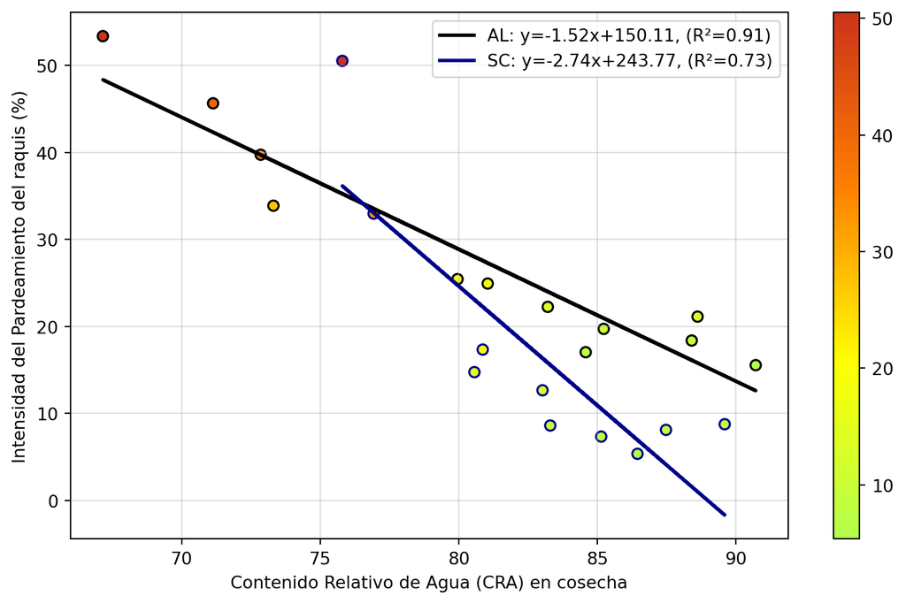

Figura 2. Relación de acuerdo CRA (%) y el pardeameinto del raquis despues de almacenamiento ( 10 dias a 0°C)

```python
#  Correlacion de acuerdo CRA vs pardeamiento
datos_CRA = pd.read_csv(r'../datos/Contenido relativo de agua.csv', sep=';')

# Calculamos el promedio  CAR en T0
CRA_promedio_T0 = (
    datos_CRA
    .groupby(['Productor', 'Variedad', 'Color', 'Tratamientos'])['CAR']
    .mean()
    .round(2)
    .reset_index()
)

# Filtrar pardeamiento T10
Pardo_t10 = df[df['Tiempo'] == 'T10']

# Calculamos el promedio pardeamiento T10
Pardo_promedio_T10 = (
    Pardo_t10
    .groupby(['Productor', 'Variedad', 'Color', 'Tratamientos'])['Pardo']
    .mean()
    .round(2)
    .reset_index()
)

# Unión de los promedios
CAR_VS_PAR = pd.merge(
    CRA_promedio_T0,
    Pardo_promedio_T10,
    on=['Productor', 'Variedad', 'Color', 'Tratamientos']
)

# Colormap
colors = [
    (0.7, 1.0, 0.3),   # Verde amarillento
    (1.0, 1.0, 0.0),   # Amarillo
    (1.0, 0.5, 0.0),   # Naranja
    (0.8, 0.2, 0.1)    # Pardo/rojo degradado
]
cmap_rav1 = mcolors.LinearSegmentedColormap.from_list("verde_a_pardo", colors, N=256)

# Crear gráfico
plt.figure(figsize=(8, 5))
variedades = CAR_VS_PAR['Variedad'].unique()

# Colores de línea (puedes cambiarlos si quieres)
colores_linea = ['black', 'darkblue']

# Colores de borde recomendados por variedad
colores_borde = {
    'AL': 'black',
    'SC': 'darkblue'
}

# === Scatter con borde por variedad ===
for variedad in variedades:
    datos_var = CAR_VS_PAR[CAR_VS_PAR['Variedad'] == variedad]

    plt.scatter(
        datos_var['CAR'],
        datos_var['Pardo'],
        c=datos_var['Pardo'],          # color interior por colormap
        cmap=cmap_rav1,
        edgecolors=colores_borde[variedad],  # borde diferenciado
        linewidth=1.2
    )

# === Regresión lineal por variedad ===
for i, variedad in enumerate(variedades):
    datos = CAR_VS_PAR[CAR_VS_PAR['Variedad'] == variedad]
    X = datos[['CAR']].values
    y = datos['Pardo'].values

    modelo = LinearRegression()
    modelo.fit(X, y)
    y_pred = modelo.predict(X)

    r2 = r2_score(y, y_pred)
    pendiente = modelo.coef_[0]
    intercepto = modelo.intercept_

    plt.plot(
        X, y_pred,
        color=colores_linea[i % len(colores_linea)],
        lw=2,
        label=f'{variedad}: y={pendiente:.2f}x+{intercepto:.2f}, (R²={r2:.2f})'
    )

# Formato final
plt.xlabel('Contenido Relativo de Agua (CRA) en cosecha')
plt.ylabel('Intensidad del Pardeamiento del raquis (%)')
plt.colorbar()
plt.grid(alpha=0.4)
plt.legend(frameon=True)
plt.tight_layout()
plt.show()
```

### 3. Almacenamiento comercial en poscosecha.

En Sweet Celebration (SC), el pardeamiento inicial fue marcadamente menor que en AL, con medianas cercanas al 15–20 % en T40 para ambos colores. Sin embargo, al pasar a T43, los raquis amarillos exhibieron un incremento notable, alcanzando valores alrededor de 45–50 %, mientras que los raquis verdes mantuvieron niveles moderados, generalmente por debajo del 30 %. Este comportamiento indica que SC expresa una menor intensidad inicial de pardeamiento, pero puede experimentar aumentos significativos cuando el almacenamiento se prolonga.

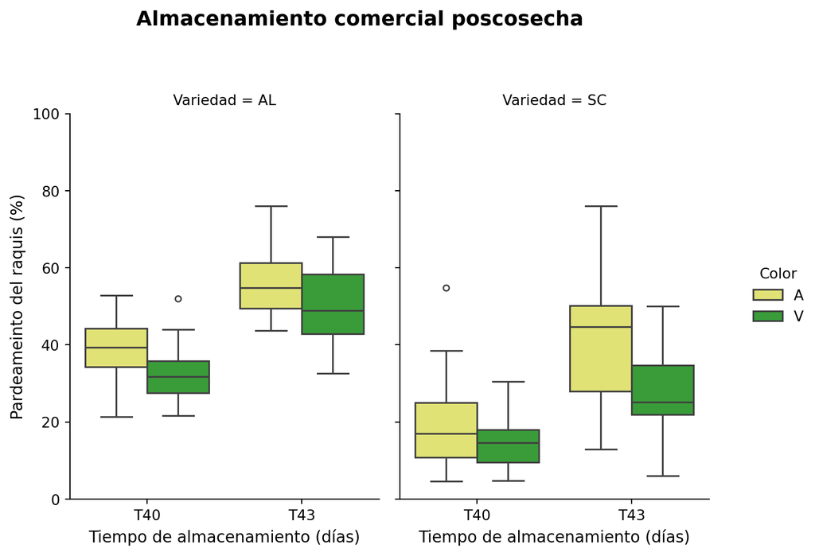

Figura 3. Intensidad pardeamineto del raquis en las variedades ‘Allison’ (AL) y ‘Sweet Celebration’ (SC) a los 40 días a 0°C (T40) y 40 días + 3 días a 20°C (T43) de almacenamiento comercial. Los colores indican la clasificación visual del raquis en cosecha (A = amarillo; V = verde).

```python
# Cargar datos
df = pd.read_csv(r'../datos/Almacenamiento comercial.csv', sep=';')
df.columns = df.columns.str.strip()

# Orden de niveles de tiempo
orden_tiempo = ['T40', 'T43']
if set(orden_tiempo).issuperset(df['Tiempo'].unique()):
    df['Tiempo'] = pd.Categorical(df['Tiempo'], categories=orden_tiempo, ordered=True)

# Paleta de colores
colores = {
    'A': "#f2f464",   # Amarillo
    'V': "#29ac29"    # Verde
}

# Crear boxplot facetado con tamaño ajustado
g = sns.catplot(
    data=df,
    kind='box',
    x='Tiempo',
    y='Pardo',
    hue='Color',
    col='Variedad',
    palette=colores,
    height=5,          # ← Alto de cada subfigura
    aspect=1.2,        # ← Relación ancho/alto
    fliersize=4,
    linewidth=1.2
)

# Ajustar tamaño total de la figura
g.fig.set_size_inches(7, 5)

# Ajustar leyenda
g._legend.set_bbox_to_anchor((1.12, 0.5))

# Ajustes finales — Escala Y fija
for ax in g.axes.flatten():
    ax.set_ylim(0, 100)
    ax.set_ylabel("Pardeameinto del raquis (%)", fontsize=11)
    ax.set_xlabel("Tiempo de almacenamiento (días)", fontsize=11)
    ax.tick_params(axis='both', labelsize=10)

# Título general
g.fig.suptitle(
    "Almacenamiento comercial poscosecha",
    y=1.06,
    fontsize=14,
    fontweight='bold'
)

plt.tight_layout()
plt.show()
```

## Conclusiones

Los raquis con tonalidades más amarillentas presentaron una mayor susceptibilidad al pardeamiento bajo condiciones comerciales de almacenamiento, lo que refuerza la importancia de considerar el estado fisiológico del tejido al momento de la cosecha.

Finalmente, se destaca la necesidad de profundizar en investigaciones futuras que incluyan nuevos cultivares comerciales, con el fin de validar y ampliar la aplicabilidad de estos indicadores en la gestión poscosecha de la uva de mesa